# Data Preparation

Shir Goldfarb, Ofek Glik & Alon Samocha

18 June 2022

## 1. Import and Transform Raw Data & Import R Libraries

#### 1.1. Import Relevant Libraries

```r
library(tidyverse)
library(zoo)
library(knitr)
library(ggthemes)
library(ggmap)
library(lubridate)
```

#### 1.2. Set global options and notebook’s theme

```r
my_theme <- theme_fivethirtyeight() +
  theme(axis.title= element_text(face="bold", size=12),
        legend.text= element_text(),
        legend.title= element_text(),
        legend.direction = "vertical",
        legend.position="right")
theme_set(my_theme)
columns_to_show <- c("acq_date", "satellite", "daynight", "brightness", "frp", "confidence", "longitude", "latitude")
```

#### 1.3. Import Raw Data

```r
aus_rainfall <- read.csv("./data/raw-data/aus_rainfall.csv")
aus_temperature <- read.csv("./data/raw-data/aus_temp.csv")
aus_fires1 <- read.csv("./data/raw-data/fire_archive_M-C61_270827.csv")
aus_fires2 <- read.csv("./data/raw-data/fire_nrt_M-C61_270827.csv")
isr_temperature <- read.csv("./data/raw-data/isr_temp.csv")
isr_rainfall <- read.csv("./data/raw-data/isr_rainfall.csv")
isr_fires1 <- read.csv("./data/raw-data/fire_archive_M-C61_271256.csv")
isr_fires2 <- read.csv("./data/raw-data/fire_nrt_M-C61_271256.csv")
isr_fires3 <- read.csv("./data/raw-data/fire_archive_SV-C2_271258.csv")
isr_fires4 <- read.csv("./data/raw-data/fire_nrt_J1V-C2_271257.csv")
isr_fires5 <- read.csv("./data/raw-data/fire_nrt_SV-C2_271258.csv")
```

#### 1.3. Combine Relevant Data Frames and Remove Unneccessary Columns

```r
aus_fires1 <- aus_fires1 %>% select(-c(instrument, type,version))
aus_fires2 <- aus_fires2 %>% select(-c(instrument, version))
aus_fires <- bind_rows(aus_fires1,aus_fires2)
aus_fires <- aus_fires %>% select(c(acq_date, acq_time, satellite, daynight, brightness,
                            bright_t31, confidence, scan, track, frp, longitude, latitude))

isr_fires1 <- isr_fires1 %>% select(-version)
isr_fires2 <- isr_fires2 %>% select(-version)
isr_fires3 <- isr_fires3 %>% select(-c(version, confidence, satellite))
isr_fires4 <- isr_fires4 %>% select(-c(version, confidence, satellite))
isr_fires5 <- isr_fires5 %>% select(-c(version, confidence, satellite))
isr_fires <- bind_rows(isr_fires1, isr_fires2, isr_fires3, isr_fires4, isr_fires5)
isr_fires <- isr_fires %>%
              select(c(acq_date, acq_time, satellite, instrument, daynight, brightness,
                            bright_t31, confidence, scan, track, frp, longitude, latitude))
```

#### 1.4. Transform Data Types and Sort by Date

```r
aus_fires <- aus_fires %>% transform(acq_date = as.Date(acq_date)) %>% arrange(acq_date, acq_time)
isr_fires <- isr_fires %>% transform(acq_date = as.Date(acq_date)) %>% arrange(acq_date, acq_time)
aus_temperature <- aus_temperature %>% transform(date = as.Date(date)) %>% arrange(date)
aus_rainfall <- aus_rainfall %>% transform(date = as.Date(date)) %>% arrange(date)
isr_temperature <- isr_temperature %>% transform(date = as.Date(date, format="%d-%m-%Y")) %>% arrange(date)
isr_rainfall <- isr_rainfall %>% transform(date = as.Date(date, format="%d-%m-%Y")) %>% arrange(date)
```

## 2. Exploratory Data Analysis

#### 2.1. Examine each of the datasets

```r
kable(head(aus_fires %>% select(columns_to_show)), align="c", caption="Australia Fires")
```

Australia Fires

| acq_date | satellite | daynight | brightness | frp | confidence | longitude | latitude |
| --- | --- | --- | --- | --- | --- | --- | --- |
| 2010-01-01 | Terra | D | 325.3 | 63.3 | 55 | 125.7380 | -18.0096 |
| 2010-01-01 | Terra | D | 351.0 | 107.9 | 95 | 139.9048 | -20.1432 |
| 2010-01-01 | Terra | D | 318.7 | 15.3 | 34 | 139.9961 | -20.0974 |
| 2010-01-01 | Terra | D | 317.5 | 16.0 | 19 | 140.1301 | -19.8168 |
| 2010-01-01 | Terra | D | 317.5 | 15.2 | 19 | 140.1143 | -19.8149 |
| 2010-01-01 | Terra | D | 351.2 | 108.1 | 96 | 139.8895 | -20.1413 |

```r
kable(tail(aus_temperature), align="c", caption="Australia Temperatures")
```

Australia Temperatures

|  | date | city_name | station_name | station_number | temperature | accumulation_days | quality | min.max | long | lat |
| --- | --- | --- | --- | --- | --- | --- | --- | --- | --- | --- |
| 286527 | 2022-05-15 | Sydney | Sydney Observatory Hill | 66214 | 18.2 | 1 | N | min | 151.20 | -33.86 |
| 286528 | 2022-05-15 | Adelaide | Adelaide Airport | 23034 | 13.7 | 1 | N | min | 138.52 | -34.95 |
| 286529 | 2022-05-15 | Subiaco | Swanbourne | 9215 | 13.4 | 1 | N | min | 115.76 | -31.96 |
| 286530 | 2022-05-15 | Darwin | Darwin Airport | 14015 | 25.4 | 1 | N | min | 130.89 | -12.42 |
| 286531 | 2022-05-15 | Canberra | Canberra Airport | 70351 | 14.1 | 1 | N | min | 149.20 | -35.31 |
| 286532 | 2022-05-15 | Melbourne | Melbourne Olympic Park | 86338 | 14.3 | 1 | N | min | 144.98 | -37.83 |

```r
kable(tail(aus_rainfall), align="c", caption="Australia Rainfall")
```

Australia Rainfall

|  | date | city_name | station_name | station_number | amount | period | quality | long | lat |
| --- | --- | --- | --- | --- | --- | --- | --- | --- | --- |
| 156126 | 2022-05-13 | Canberra | Canberra Airport | 70351 | 27.0 | 1 | N | 149.20 | -35.31 |
| 156127 | 2022-05-13 | Brisbane | Brisbane Botanic Gardens | 40976 | 76.0 | 1 | N | 152.98 | -27.48 |
| 156128 | 2022-05-14 | Sydney | Sydney Observatory Hill | 66214 | 0.4 | 1 | N | 151.20 | -33.86 |
| 156129 | 2022-05-14 | Canberra | Canberra Airport | 70351 | 0.2 | 1 | N | 149.20 | -35.31 |
| 156130 | 2022-05-15 | Canberra | Canberra Airport | 70351 | 1.6 | 1 | N | 149.20 | -35.31 |
| 156131 | 2022-05-15 | Sydney | Sydney Observatory Hill | 66214 | 0.2 | 1 | N | 151.20 | -33.86 |

```r
kable(tail(isr_fires %>% select(columns_to_show)), align="c", caption="Israel Fires")
```

Israel Fires

|  | acq_date | satellite | daynight | brightness | frp | confidence | longitude | latitude |
| --- | --- | --- | --- | --- | --- | --- | --- | --- |
| 18894 | 2022-05-16 | NA | N | 297.67 | 0.50 | NA | 34.91714 | 31.91529 |
| 18895 | 2022-05-16 | NA | N | 300.46 | 0.56 | NA | 34.89601 | 31.91660 |
| 18896 | 2022-05-16 | NA | N | 299.90 | 0.43 | NA | 34.89519 | 31.91529 |
| 18897 | 2022-05-16 | NA | N | 315.97 | 1.64 | NA | 35.09292 | 32.88979 |
| 18898 | 2022-05-16 | NA | N | 321.09 | 2.12 | NA | 35.08951 | 32.88856 |
| 18899 | 2022-05-17 | NA | D | 336.27 | 3.15 | NA | 35.09234 | 32.88756 |

As we can see, the `confidence` column in the above table has missing values. Let’s check how common that is.

```r
kable(summary(isr_fires %>% select(columns_to_show)))
```

|  | acq_date | satellite | daynight | brightness | frp | confidence | longitude | latitude |
| --- | --- | --- | --- | --- | --- | --- | --- | --- |
|  | Min. :2010-01-07 | Length:18899 | Length:18899 | Min. :208.0 | Min. : 0.10 | Min. : 0.00 | Min. :34.26 | Min. :29.53 |
|  | 1st Qu.:2014-07-09 | Class :character | Class :character | 1st Qu.:303.8 | 1st Qu.: 1.02 | 1st Qu.: 55.50 | 1st Qu.:34.89 | 1st Qu.:31.76 |
|  | Median :2017-06-12 | Mode :character | Mode :character | Median :313.8 | Median : 1.83 | Median : 69.00 | Median :35.00 | Median :31.97 |
|  | Mean :2017-05-20 | NA | NA | Mean :321.1 | Mean : 8.25 | Mean : 68.14 | Mean :35.06 | Mean :32.24 |
|  | 3rd Qu.:2020-07-25 | NA | NA | 3rd Qu.:337.7 | 3rd Qu.: 6.37 | 3rd Qu.: 82.00 | 3rd Qu.:35.19 | 3rd Qu.:32.89 |
|  | Max. :2022-05-17 | NA | NA | Max. :410.0 | Max. :947.20 | Max. :100.00 | Max. :35.89 | Max. :33.33 |
|  | NA | NA | NA | NA | NA | NA’s :17040 | NA | NA |

Using the summary function we can learn that out of 19,000~ records in this table, more than 17,000 have NA `confidence` columns. Since `confidence` gives us certainty about the occurrence of fires, we will need to understand how we can fill those values using other features.

```r
kable(tail(isr_temperature), align="c", caption="Israel Temperature")
```

Israel Temperature

|  | X | station_name | station_number | date | max_temp | min_temp | min_temp_ground | light_time | lightnings | long | lat |
| --- | --- | --- | --- | --- | --- | --- | --- | --- | --- | --- | --- |
| 30836 | 8920 | Eilat | 9974 | 2022-01-01 | - | - | - | - | - | 34.9464 | 29.5576 |
| 30837 | 13304 | Haifa-Technion | 850 | 2022-01-01 | 16.2 | 10.8 | - | - | - | 35.0228 | 32.7768 |
| 30838 | 17688 | Jerusalem Center | 6771 | 2022-01-01 | 11.0 | 8.4 | - | - | - | 35.2134 | 31.7844 |
| 30839 | 22072 | Kfar Blum | 8472 | 2022-01-01 | 20.8 | 13.8 | 11.2 | - | - | 35.6074 | 33.1714 |
| 30840 | 26456 | Tel Aviv Beach | 2410 | 2022-01-01 | 19.4 | 14.3 | - | - | - | 34.7673 | 32.0790 |
| 30841 | 30840 | The Negev Junction | 7972 | 2022-01-01 | 15.5 | 10.8 | - | - | - | 34.8388 | 31.0665 |

```r
kable(tail(isr_rainfall), align="c", caption="Israel Rainfall")
```

Israel Rainfall

|  | X | station_name | station_number | date | daily_amount | daily_rain_code | long | lat |
| --- | --- | --- | --- | --- | --- | --- | --- | --- |
| 3479 | 3483 | Kfar Blum | 310552 | 2021-12-31 | 1.1 | 0 | 35.6074 | 33.1714 |
| 3480 | 455 | Beer Sheva | 251691 | 2022-01-01 | 1.1 | 0 | 34.7867 | 31.2574 |
| 3481 | 1135 | Beit Dagan | 136741 | 2022-01-01 | 1.0 | 0 | 34.8297 | 32.0013 |
| 3482 | 1253 | Eilat | 347704 | 2022-01-01 | 0.5 | 7 | 34.9464 | 29.5576 |
| 3483 | 2048 | Haifa-Technion | 120530 | 2022-01-01 | 0.1 | 0 | 35.0228 | 32.7768 |
| 3484 | 2692 | Jerusalem Center | 244731 | 2022-01-01 | 0.8 | 0 | 35.2134 | 31.7844 |

#### 2.2. Visualizations

##### 2.2.1 Australia Fires - Plot latest fires locations

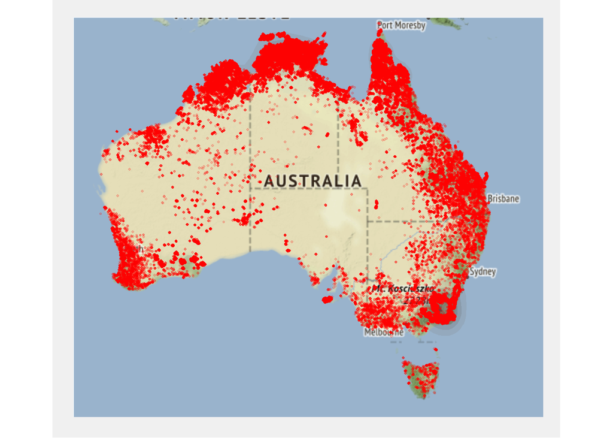

```r
late_fires <- aus_fires %>% filter(acq_date >= as.Date('2020-01-01'), acq_date < as.Date('2021-01-01'))
sbbox <- make_bbox(lon = c(115, 155), lat = c(-12.5, -42), f = .1)
ausbg = get_map(location=sbbox, zoom=4,
                source = "osm",
                color = "color",
                maptype="satellite")
ausbg = ggmap(ausbg)
ausbg +
  stat_density2d(data = late_fires, aes(x = longitude, y= latitude,
                     fill = ..level..,  alpha = I(.2)),
                 size = 1, bins = 5, geom = "polygon") +
  geom_point(data = late_fires, mapping = aes(x=longitude, y= latitude),
             color="red", alpha = .2, size=late_fires$brightness/500) +
  # define color of density polygons
  scale_fill_gradient(low = "grey50", high = "grey20") +
  theme(axis.line=element_blank(),
        axis.text.x=element_blank(),
        axis.text.y=element_blank(),
        axis.ticks=element_blank(),
        axis.title.x=element_blank(),
        axis.title.y=element_blank(),
        panel.background = element_rect(fill = "aliceblue",
                                colour = "aliceblue"),
        panel.grid.major = element_blank(),
        panel.grid.minor = element_blank(),
        # supress legend
        legend.position = "none")
```

##### 2.2.2 Israel Fires - Plot latest fires locations

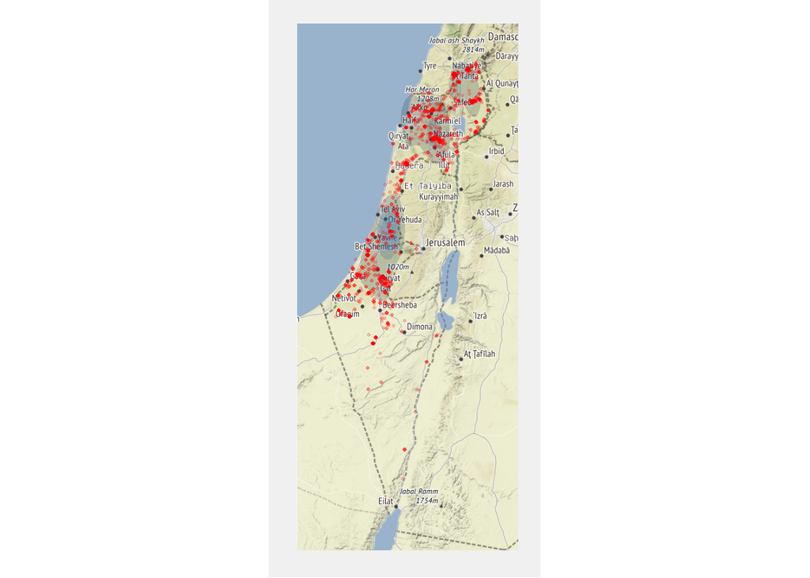

##### 2.2.3 Australia Fires - `Confidence` vs `Brightness` by `daynight`

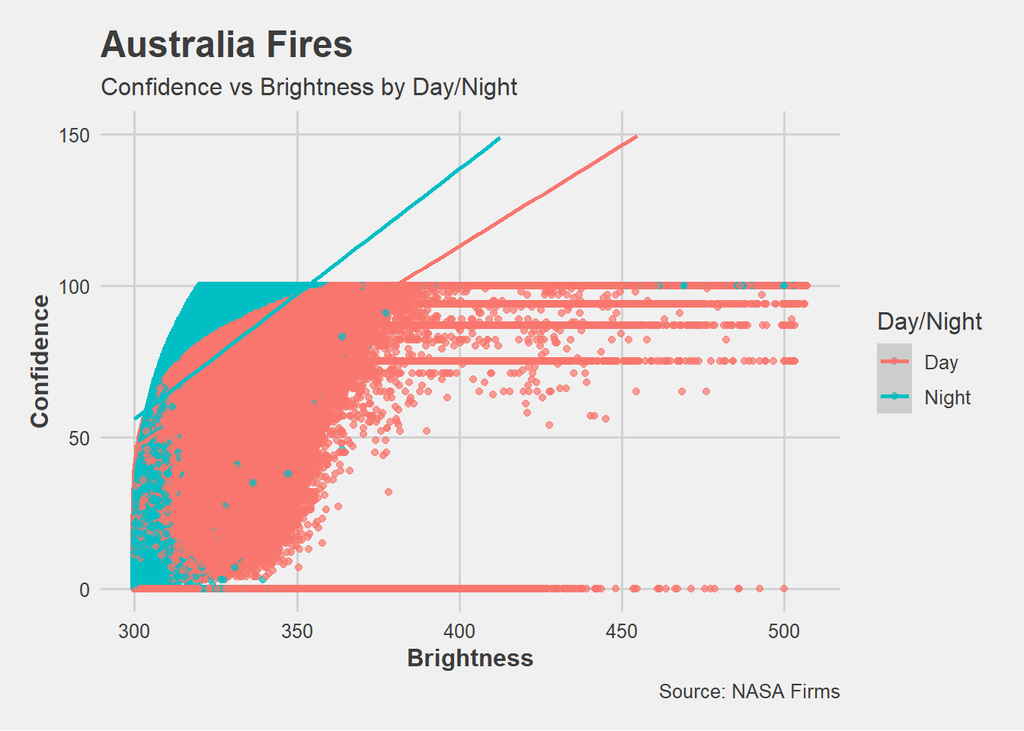

```r
aus_fires %>% ggplot(aes(x=brightness, y=confidence, color=daynight)) +
              geom_point(alpha=0.7) +
              geom_smooth(method="lm") +
              ylim(0, 150) +
              labs(title = "Australia Fires",
                   subtitle = "Confidence vs Brightness by Day/Night",
                   x = "Brightness",
                   y = "Confidence",
                   caption = "Source: NASA Firms") +
              scale_color_discrete(name="Day/Night", labels=c("Day", "Night"))
```

##### 2.2.4 Australia Fires - `Confidence` vs `Fire Radiative Power`

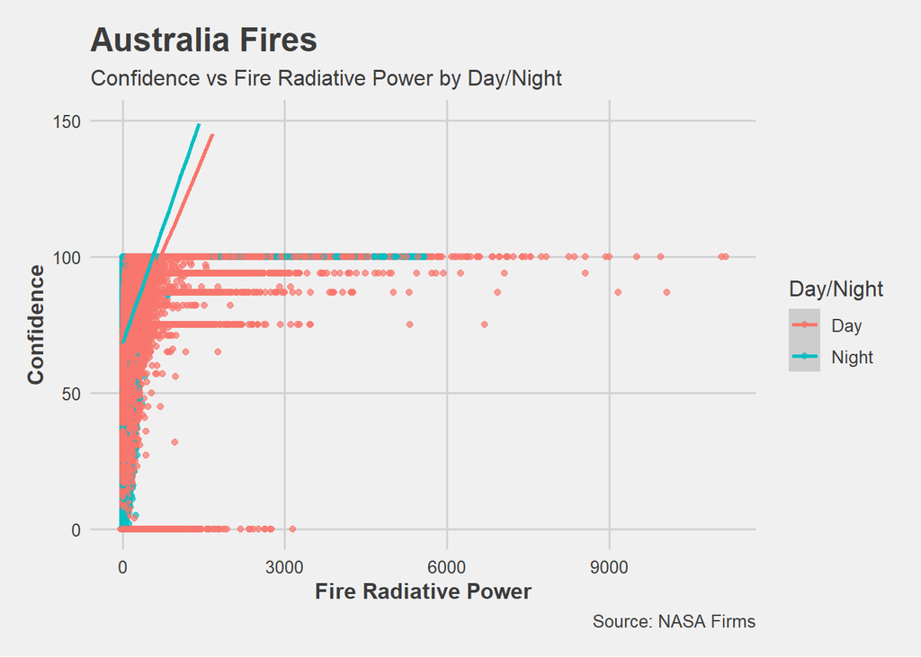

```r
aus_fires %>% ggplot(aes(x=frp, y=confidence, color=daynight)) +
              geom_point(alpha=0.7) +
              geom_smooth(method="lm") +
              ylim(0, 150) +
              labs(title = "Australia Fires",
                   subtitle = "Confidence vs Fire Radiative Power by Day/Night",
                   x = "Fire Radiative Power",
                   y = "Confidence",
                   caption = "Source: NASA Firms") +
              scale_color_discrete(name="Day/Night", labels=c("Day", "Night"))
```

As we can see in the 2 plots above, we have certain `confidence` values that act as anomalies. We will filter those values in order to reduce the noise and make our model more reliable in the future. Also, we can see that there are significant differences in the way that `brightness` behaves in day and night. In order to make our data more stable and predictable, we will work with fires that occurred in the day only from now on. Most importantly, we can learn that there is a clear correlation between between `confidence`, `brightness` and `frp`. We will use this relationship in order to fill the missing `confidence` values in the Israeli Fires table.